# ART-C Analysis and Visualizations

Lisa A. Elkin, Matthew Kay, James J. Higgins, Jacob O. Wobbrock

# Intro

If you’ve come here after reading our paper because you’re curious about how we did our analysis and made our visualizations, welcome! If not, you can find the paper [here](https://doi.org/10.1145/3472749.3474784) for some more technical details.

Either way, we’ll start with a short recap about what we’re doing and why.

The ART procedure is a nonparametric data analysis method that aligns and ranks data, and the resulting aligned and ranked data can be analyzed by an ANOVA. It’s become popular because it’s simple to use and unlike other popular nonparametric methods, it can find interaction effects. It can also be used to conduct contrasts that compare levels within a single factor (i.e., posthoc tests following a significant main effect), but it can’t be used to conduct contrasts that involve levels of multiple factors (i.e., posthoc tests following a significant interaction effect). So, we created a new method, ART-C, that uses a different procedure to align and rank data and can be used to conduct multifactor contrasts.

We define a *design* as a unique combination of:

**Layout**: The number of factors and number of levels per factor in the data set.  
Values: two factors with two levels each (2 $\times$ 2), two factors with three levels each (3 $\times$ 3), and three factors with two levels each (2 $\times$ 2 $\times$ 2).  
Column name in logs: Layout

**Population Distribution**: We define population as a distribution and the values of its parameters (e.g. a normal distribution with location = 0 and scale = 1). The term Population Distribution refers only to the type of distribution and not the values of its parameters (e.g. normal distribution).  
Values are: Normal, Lognormal, Exponential, Cauchy, *t*(3), Double Exponential.  
Column name in logs: Population_Distribution

**Condition Sample Size**: The number of data points randomly sampled from a population for each condition.  
Values: 8, 16, 24, 32, and 40.  
Column name in logs: Condition_Sample_Size

**Between or Within Subjects**: Whether the data is from a between-subjects study or a within-subjects study.  
Values: B, W.  
Column name in logs: BW

**Contrast Size**: The number of factors whose levels are compared in a contrast.  
Values: 1-Factor Contrasts, 2-Factor Contrasts, 3-Factor Contrasts.  
Column name in logs: Contrast_Size.

We made 72,000 synthetic data sets (approximately 400 for each possible design) and evaluated our new procedure on two metrics: Type I error rate and statistical power. All of the Population Distributions have **location** parameter (e.g., normal distribution’s mean is its location parameter and the lognormal distributions logmean is its location parameter).

To measure Type I error rates, we made approximately 200 data sets for each possible design in which every condition within a single data set had the same location. This meant that the true difference between conditions was always 0, so any time a significant difference we was (i.e., *p* < .05), that was a Type I error. For each design, we counted up the number of times *p* was *< .05* and divided that by the total number of tests we did for that design – this is called the *observed Type I error rate*.

To measure power, we made approximately 200 data sets for each possible design in which every condition with a single data set had different locations. This meant that there was always a true difference between conditions. So, for each design, we counted up the number of times *p* was *< .05* and divided that by the total number of tests we did for that design – this is called the *observed statistical power*.

The code we used to calculate observed Type I error and observed statistical power for our raw logs can be found [here](https://github.com/lelkin/ART_Contrasts_Analysis/blob/test/process_raw_logs.md), but it’s not the nicest code I’ve ever written, and we really just counted how many times we saw *p < .05* and how many tests we did and divide.

Alright, now that we’ve sifted through some definitions, we can look at some descriptive statistics and visualizations that compare ART-C to other methods, including the original ART.

We focus on our large-scale analysis, but if you’d like to see an example that illustrates the problems with using ART to conduct multifactor contrasts and how to use the R package we wrote to conduct multifactor contrasts with ART-C, take a look at the [package vignette](https://cran.r-project.org/web/packages/ARTool/vignettes/art-contrasts.html). If you’d like to read a paper on the original ART method, you can find that [here](https://dl.acm.org/doi/abs/10.1145/1978942.1978963?casa_token=ZuKwCmxP2iMAAAAA:kF4sSIULiGXilE0NCmmVC6oHnfUI7P8Ffe1F-M2B5gHj9HgOZ_vYM43NUkaCKvzqWDNVZjI0eflAlg).

# Setup

We start by reading in the data and making all factors factors. Each row has the proportion of significant results over all trials for a single design.

```r
dir_name = "./raw_logs"
df = read.csv(paste(dir_name, "/res_ults.csv", sep=""))

df$Layout = factor(df$Layout, levels=c("2x2", "3x3", "2x2x2")) # reorder Layout. needed for plots later
df$Population_Distribution = factor(df$Population_Distribution)
df$Contrast_Size = as.factor(df$Contrast_Size)
df$Condition_Sample_Size = as.factor(df$Condition_Sample_Size)
```

Using some horribly messy code that we’ve omitted, we separate df into two data frames: df_same_loc with results from all designs in which population locations were the same and will be used to measure Type I error rates, and df_diff_loc with results from all designs in which population locations were different and will be used to measure statistical power.

# Comparison with ART

So, we started by saying that we can’t use the original ART to conduct multifactor contrasts, but we’ve got to back that up with some data. We used the original ART to conduct contrasts on our 72,000 synthetic data sets and illustrate the results here. We also compare it to ART-C.

## ART Type I Error

Let’s look at some descriptive stats: the overall mean and standard deviation of Type I error for both ART-C and ART. Remember, we calculated Type I error for each design, so this is the mean and standard deviation of those per-design Type I error rates.

```
## ART Type I error mean 0.1187472
```

```
## ART Type I error SD 0.1724412
```

```
## ART-C Type I error mean: 0.06525816
```

```
## ART-C Type I error SD 0.07125876
```

The mean Type I error rate for ART is .12, which is much larger than its expected value of .05. In comparison, ART-C’s mean Type I error rate is much closer to .05, although it still seems a bit high, but that’s due to one egregious case, which we’ll discuss below.

### ART Type I error by Population Distribution

Now a more granular approach: let’s compare ART and ART-C Type I error when we split up designs by Population Distribution. First, some descriptive statistics:

ART

```r
ddply(df_same_loc, .(Population_Distribution), summarize, mean = mean(ART_Omni_Proportion_Sig), sd = sd(ART_Omni_Proportion_Sig))
```

```
##   Population_Distribution       mean         sd
## 1               Lognormal 0.14083198 0.09616724
## 2                  Normal 0.02388222 0.02315966
## 3             Exponential 0.06475505 0.04819342
## 4                  Cauchy 0.42474624 0.20933617
## 5                    t(3) 0.03270243 0.01546156
## 6      Double Exponential 0.02556511 0.02255269
```

ART-C

```r
ddply(df_same_loc, .(Population_Distribution), summarize, mean = mean(ART_Con_Proportion_Sig), sd = sd(ART_Con_Proportion_Sig))
```

```
##   Population_Distribution       mean          sd
## 1               Lognormal 0.05404593 0.015335095
## 2                  Normal 0.04884978 0.008172849
## 3             Exponential 0.05070027 0.007374186
## 4                  Cauchy 0.13988917 0.153585610
## 5                    t(3) 0.04893364 0.006285141
## 6      Double Exponential 0.04913016 0.007072491
```

Now the vizualtion. with ART in gray and ART-C in teal.

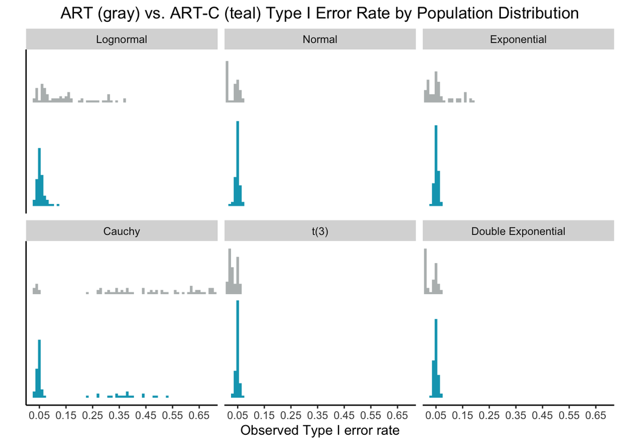

```r
# create df with only single-factor contrasts
df_same_loc_1factor = df_same_loc %>% filter(Contrast_Size == "1-Factor Contrasts")

# tick spacing
breaks.x = seq(0.05,.75,0.1)

# labels are character versions of breaks
labels.x = as.character(breaks.x)

p = ggplot(df_same_loc) +
   geom_density( aes(x = ART_Omni_Proportion_Sig, y= ..count..), stat="binline", binwidth=.01, draw_baseline=FALSE, fill="azure4",color=NA, alpha=.6, position = position_nudge(y=50)) +
   geom_density( aes(x = ART_Con_Proportion_Sig, y= ..count..), stat="binline", binwidth=.01, draw_baseline=FALSE, fill=teal,color=NA) +
  theme +
  xlab("Observed Type I error rate") +
  ylab("") +
  scale_x_continuous(breaks = breaks.x, label = labels.x, limits = range(df_same_loc$ART_Omni_Proportion_Sig), expand=c(0,0))+
  facet_wrap(~Population_Distribution, ncol=3) +
  labs(title = "ART (gray) vs. ART-C (teal) Type I Error Rate by Population Distribution")

p
```

We can see that the original ART inflates Type I error rates for data drawn from lognormal, exponential, and Cauchy populations, and for all distributions ART Type I error rates are also further from the expected value of .05 than ART-C’s. This means the orignal ART is *less correct* than ART-C because the definition of correct is “Observed Type I error rates are close to their expected value”.

We looked at how other design properties affect the differences because ART and ART-C Type I error rates and didn’t find anything interesting, but you can use the source code for this notebook to look at it yourself.

## ART Power

So, we know that ART has infalted Type I error rates, but it’s still worth looking at how its power compares to ART-C.

```
## ART power mean 0.5098959
```

```
## ART power SD 0.1838599
```

```
## ART-C power mean 0.5981218
```

```
## ART-C power SD 0.1432977
```

### ART Power by Population Distribution

Just like we did with Type I error, we group designs by Population Distribution and compare ART power to ART-C power.

ART

```r
ddply(df_diff_loc, .(Population_Distribution), summarize, mean = mean(ART_Omni_Proportion_Sig), sd = sd(ART_Omni_Proportion_Sig))
```

```
##   Population_Distribution      mean        sd
## 1               Lognormal 0.6159530 0.1435732
## 2                  Normal 0.4875290 0.1846556
## 3             Exponential 0.5838031 0.1585379
## 4                  Cauchy 0.5131002 0.1599107
## 5                    t(3) 0.4215320 0.1831623
## 6      Double Exponential 0.4374581 0.1886694
```

ART-C

```r
ddply(df_diff_loc, .(Population_Distribution), summarize, mean = mean(ART_Con_Proportion_Sig), sd = sd(ART_Con_Proportion_Sig))
```

```
##   Population_Distribution      mean        sd
## 1               Lognormal 0.6865944 0.1018846
## 2                  Normal 0.6570850 0.0909288
## 3             Exponential 0.6606709 0.1083136
## 4                  Cauchy 0.4056335 0.1346811
## 5                    t(3) 0.5779982 0.1090603
## 6      Double Exponential 0.6007488 0.1040977
```

Now vizualizing with ART in gray and ART-C in teal.

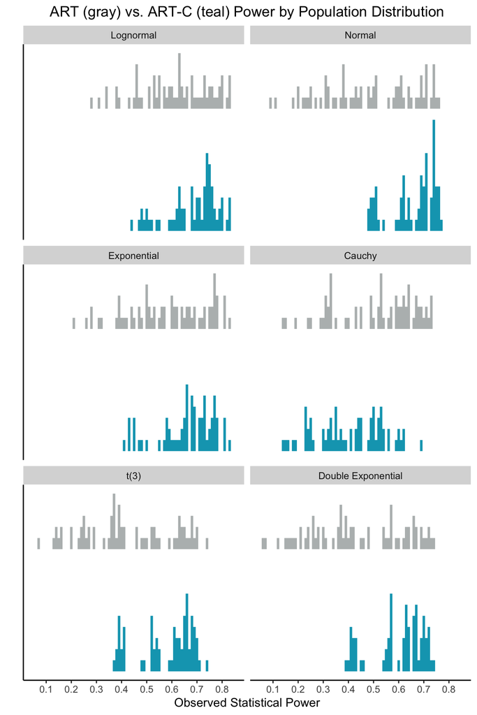

```r
# tick spacing
breaks.x = seq(0,.9,0.1)
# labels are character versions of breaks
labels.x = as.character(breaks.x)

# plot histogram of power for artcon, param, and nonparam overlapping.
p = ggplot(df_diff_loc) +
 geom_density( aes(x = ART_Omni_Proportion_Sig, y= ..count..), stat="binline", binwidth=.01, draw_baseline=FALSE, fill="azure4", color=NA, alpha=.6, position = position_nudge(y=11)) +
   geom_density( aes(x = ART_Con_Proportion_Sig, y= ..count..), stat="binline", binwidth=.01, draw_baseline=FALSE, fill=teal,color=NA) +
  theme+
  xlab("Observed Statistical Power") +
  ylab("") +
  scale_x_continuous(breaks = breaks.x, label = labels.x, limits = range(df_diff_loc$ART_Omni_Proportion_Sig)) +
  # scale_y_continuous(breaks = breaks.y, label = labels.y) +
  facet_wrap(~Population_Distribution, ncol=2)+
  labs(title = "ART (gray) vs. ART-C (teal) Power by Population Distribution")

p
```

### ART Power by Contrast Size

Contrast size also has an interesting effect on ART power (and the difference between ART and ART-C power).

ART

```r
ddply(df_diff_loc, .(Contrast_Size), summarize, mean = mean(ART_Omni_Proportion_Sig), sd = sd(ART_Omni_Proportion_Sig))
```

```
##        Contrast_Size      mean        sd
## 1 1-Factor Contrasts 0.6162018 0.1471774
## 2 2-Factor Contrasts 0.4606213 0.1514769
## 3 3-Factor Contrasts 0.3388019 0.1818883
```

ART-C

```r
ddply(df_diff_loc, .(Contrast_Size), summarize, mean = mean(ART_Con_Proportion_Sig), sd = sd(ART_Con_Proportion_Sig))
```

```
##        Contrast_Size      mean        sd
## 1 1-Factor Contrasts 0.6162018 0.1471774
## 2 2-Factor Contrasts 0.5829068 0.1416638
## 3 3-Factor Contrasts 0.5895269 0.1320799
```

Now visualizing (again, ART in gray and ART-C in teal):

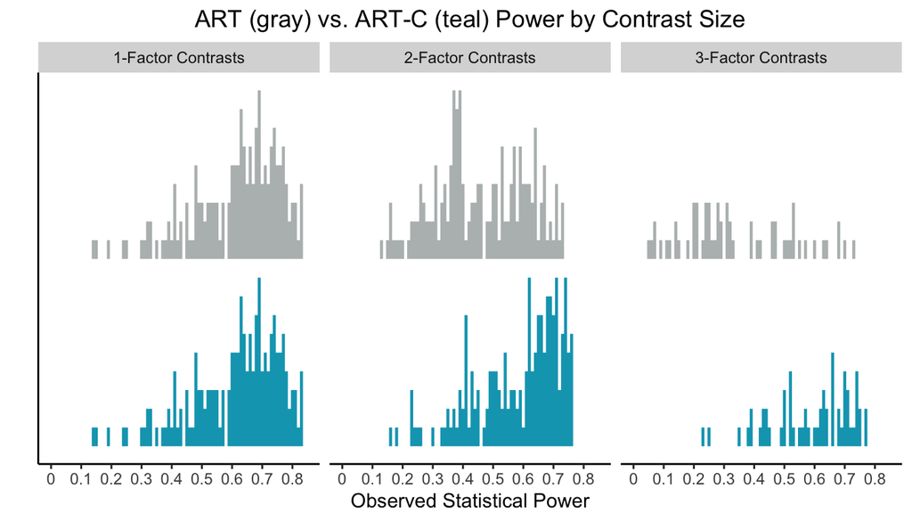

```r
# plot histogram of power for artcon, param, and nonparam overlapping.
p = ggplot(df_diff_loc) +
  geom_density( aes(x = ART_Omni_Proportion_Sig, y= ..count..), stat="binline", binwidth=.01, draw_baseline=FALSE, fill="azure4", color= NA, alpha=.6, size=.15, position = position_nudge(y=10)) +
  geom_density( aes(x = ART_Con_Proportion_Sig, y= ..count..), stat="binline", binwidth=.01, draw_baseline=FALSE, fill=teal,color=NA, size=.15) +
  theme +
  xlab("Observed Statistical Power") +
  ylab("") +
  scale_x_continuous(breaks = breaks.x, label = labels.x, limits = c(0, max(df_diff_loc$ART_Con_Proportion_Sig))) +
  facet_wrap(~Contrast_Size, nrow=1) +
  labs(title = "ART (gray) vs. ART-C (teal) Power by Contrast Size")

p
```

ART and ART-C are mathematically equivalent when analyzing 1-factor contrasts, but when we look at 2-factor contrasts and 3-factor contrasts, things get interesting. ART-C’s power is pretty similar for each Contrast Size, but ART’s power decreases as Contrast Size increases. It’s not clear why this happens, but certainly is a reason to avoid using the original ART to conduct multifactor contrasts.

# Type I Error Rate

A common practice in statistics is the use the *t*-test as a baseline comparison for Type I error rate, so that’s what we do here.

When looking at our data we saw that 1-Factor Contrasts from a 2 $\times$ 2 $\times$ 2 or 3 $\times$ 3 Layout and a Cauchy Population Distribution have very high Type I error rates. We make a new data frame with just those data sets, aptly named *df_same_loc_bad_cauchy* and look at some descriptive stats, and we use the term *bad Cauchy* to describe those designs.

```r
# descriptive stats with single factor cauchy contrasts from 2x2x2 and 3x3 distrs
df_same_loc_bad_cauchy = df_same_loc %>% filter(Population_Distribution == "Cauchy" & Contrast_Size == '1-Factor Contrasts' & Layout != "2x2")
```

ART-C

```
## ART-C bad Cauchy mean 0.3726467
```

```
## ART-C bad Cauchy SD 0.07546431
```

t-test

```
## t-test bad Cauchy mean 0.02448918
```

```
## t-test bad Cauchy sd 0.003883159
```

ART-C Type I error rates on “bad Cauchy” data are really high and the *t*-test Type I error rates aren’t. For the remainder of this Type I error rate analysis, we omit all “bad Cauchy” data. We write “no Cauchy” below, but that’s a bit misleading. It really means no Cauchy $\times$ (2 $\times$ 2 $\times$ 2 or 3 $\times$ 3) $\times$ 1-Factor Contrasts

```r
# remove single factor cauchy contrasts from 2x2x2 and 3x3 distrs since we know they're bad
df_same_loc_no_cauchy = df_same_loc %>% filter(Population_Distribution != "Cauchy" | Contrast_Size != '1-Factor Contrasts' | Layout == "2x2")
```

We look at descriptive stats for the remaining designs.

ART-C

```
## ART-C Type I error rate mean 0.04988873
```

```
## ART-C Type I error rate SD 0.009387004
```

```
## t-test Type I error rate mean 0.0477396
```

```
## t-test Type I error rate SD 0.012325
```

ART-C and the *t*-test both have mean Type I error rates really close to their expected value of .05, but the standard deviation for ART-C is much smaller, and we’ll see in the visualization that ART-C Type I error rates are more closely clustered are .05 than the *t*-test’s are.

### Type I Error by Contrast Size $\times$ Layout

None of the design properties (aside from the Cauchy scenario discussed above) have a large impact on observed Type I error rate. We chose to visualize and describe it using Contrast Size $\times$ Layout. Some descriptive stats:

ART-C

```r
ddply(df_same_loc_no_cauchy, .(Contrast_Size,Layout), summarize, mean = mean(ART_Con_Proportion_Sig), sd = sd(ART_Con_Proportion_Sig))
```

```
##        Contrast_Size Layout       mean          sd
## 1 1-Factor Contrasts    2x2 0.04611049 0.011043811
## 2 1-Factor Contrasts    3x3 0.05260397 0.008684828
## 3 1-Factor Contrasts  2x2x2 0.05693477 0.016183661
## 4 2-Factor Contrasts    2x2 0.04766285 0.007782842
## 5 2-Factor Contrasts    3x3 0.05014737 0.004387717
## 6 2-Factor Contrasts  2x2x2 0.04839978 0.004793275
## 7 3-Factor Contrasts  2x2x2 0.04898875 0.004466714
```

T-test

```r
ddply(df_same_loc_no_cauchy, .(Contrast_Size,Layout), summarize, mean = mean(Param_Proportion_Sig), sd = sd(Param_Proportion_Sig))
```

```
##        Contrast_Size Layout       mean          sd
## 1 1-Factor Contrasts    2x2 0.03950532 0.013769937
## 2 1-Factor Contrasts    3x3 0.04806399 0.006819141
## 3 1-Factor Contrasts  2x2x2 0.04769974 0.008688110
## 4 2-Factor Contrasts    2x2 0.04227875 0.008597558
## 5 2-Factor Contrasts    3x3 0.05771661 0.015502498
## 6 2-Factor Contrasts  2x2x2 0.04504088 0.007441326
## 7 3-Factor Contrasts  2x2x2 0.05391930 0.010950598
```

Now Visualizing.

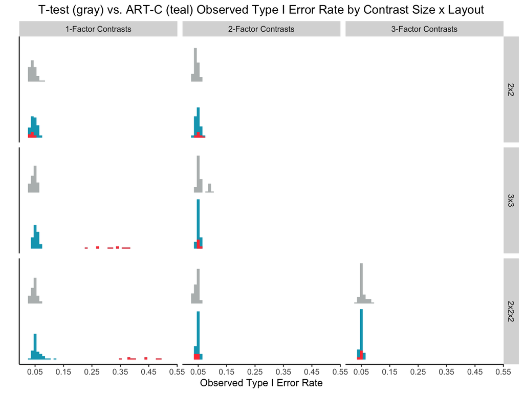

```r
# df_same_loc_bad_cauchy is only the cauchy distrs with 1-factor contrasts and 3x3 or 2x2x2 designs. This is all of them
df_same_loc_just_cauchy = df_same_loc %>% filter(Population_Distribution == "Cauchy")

# tick spacing
breaks.x = seq(0.05,1,0.1)

# labels are character versions of breaks
labels.x = as.character(breaks.x)

p =ggplot(df_same_loc) +
 geom_density( aes(x = Param_Proportion_Sig, y= ..count..), stat="binline", binwidth=.01, draw_baseline=FALSE, fill="azure4", color = NA, alpha=.6,
               position = position_nudge(y=50)) +
 geom_density( aes(x = ART_Con_Proportion_Sig, y= ..count..), stat="binline", binwidth=.01, draw_baseline=FALSE, fill=teal, color=NA) +
 geom_density( data = df_same_loc_just_cauchy, aes(x = ART_Con_Proportion_Sig, y= ..count..), stat="binline", binwidth=.01, draw_baseline=FALSE, fill="brown1",color=NA) +
theme+
  # set x-axis label
  xlab("Observed Type I Error Rate") +
  # set y-axis label to nothing
  ylab("") +
  scale_x_continuous(breaks = breaks.x, label = labels.x, limits = (range(df_same_loc$ART_Con_Proportion_Sig))) +
  facet_grid(Layout~Contrast_Size, scale="free_x")+
  labs(title = "T-test (gray) vs. ART-C (teal) Observed Type I Error Rate by Contrast Size x Layout")

# show plot p
p
```

We didn’t look at how other properties impact Type I error in our paper, but we’ll look at them here.

### Type I Error by Condition Sample Size

Note that we are still excluding data drawn from a Cauchy Distribution here. Descriptive stats:

ART-C

```r
ddply(df_same_loc_no_cauchy, .(Condition_Sample_Size), summarize, mean = mean(ART_Con_Proportion_Sig), sd = sd(ART_Con_Proportion_Sig))
```

```
##   Condition_Sample_Size       mean          sd
## 1                     8 0.05224353 0.012283575
## 2                    16 0.05012786 0.009301392
## 3                    24 0.04868225 0.008375107
## 4                    32 0.04918884 0.008325407
## 5                    40 0.04920116 0.007749958
```

T-test

```r
ddply(df_same_loc_no_cauchy, .(Condition_Sample_Size), summarize, mean = mean(Param_Proportion_Sig), sd = sd(Param_Proportion_Sig))
```

```
##   Condition_Sample_Size       mean         sd
## 1                     8 0.04726386 0.01277286
## 2                    16 0.04749995 0.01246879
## 3                    24 0.04792999 0.01196373
## 4                    32 0.04798227 0.01295795
## 5                    40 0.04802191 0.01170892
```

Now visualizing

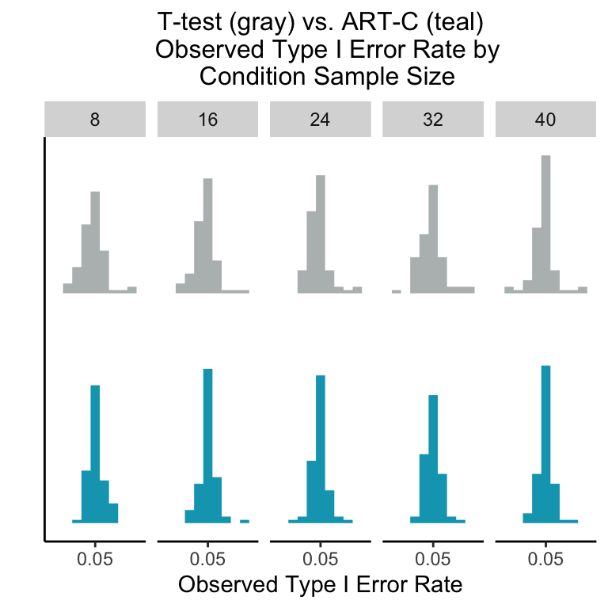

```r
# tick spacing
breaks.x = seq(0.05,1,0.1)

# labels are character versions of breaks
labels.x = as.character(breaks.x)

p =ggplot(df_same_loc_no_cauchy) +
 geom_density( aes(x = Param_Proportion_Sig, y= ..count..), stat="binline", binwidth=.01, draw_baseline=FALSE, fill="azure4", color = NA, alpha=.6,
               position = position_nudge(y=70)) +
 geom_density( aes(x = ART_Con_Proportion_Sig, y= ..count..), stat="binline", binwidth=.01, draw_baseline=FALSE, fill=teal, color=NA) +
theme+
theme(plot.title = element_text(color = "black",hjust=.5,size=12)) +
  # set x-axis label
  xlab("Observed Type I Error Rate") +
  # set y-axis label to nothing
  ylab("") +
  facet_wrap(~Condition_Sample_Size, nrow=1) +
  scale_x_continuous(breaks = breaks.x, label = labels.x, limits = c(0,.1)) +
  labs(title = "T-test (gray) vs. ART-C (teal)
  Observed Type I Error Rate by
  Condition Sample Size")

# show plot p
p
```

### Type I Error by Between or Within Subecjets

Descriptive stats:

ART-C

```r
ddply(df_same_loc_no_cauchy, .(BW), summarize, mean = mean(ART_Con_Proportion_Sig), sd = sd(ART_Con_Proportion_Sig))
```

```
##                 BW       mean          sd
## 1 Between Subjects 0.04878041 0.008506636
## 2  Within Subjects 0.05099705 0.010091705
```

T-test

```r
ddply(df_same_loc_no_cauchy, .(BW), summarize, mean = mean(Param_Proportion_Sig), sd = sd(Param_Proportion_Sig))
```

```
##                 BW       mean         sd
## 1 Between Subjects 0.04769404 0.01232468
## 2  Within Subjects 0.04778515 0.01235608
```

Now visualizing

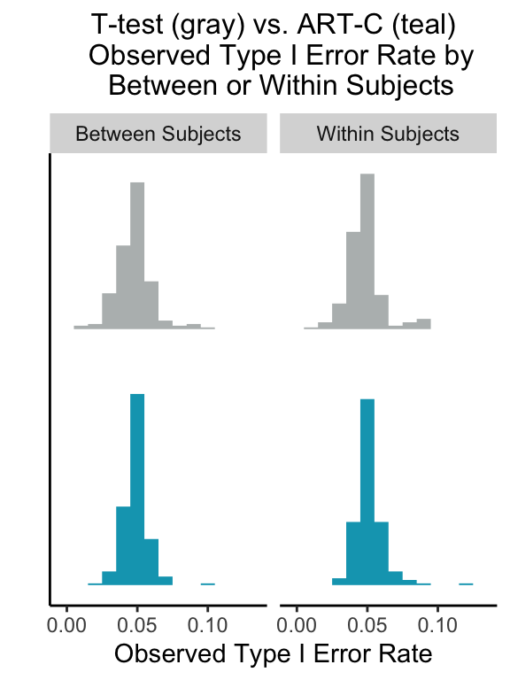

```r
# tick spacing
breaks.x = seq(0.05,1,0.1)

# labels are character versions of breaks
labels.x = as.character(breaks.x)

p =ggplot(df_same_loc_no_cauchy) +
 geom_density( aes(x = Param_Proportion_Sig, y= ..count..), stat="binline", binwidth=.01, draw_baseline=FALSE, fill="azure4", color = NA, alpha=.6,
               position = position_nudge(y=150)) +
 geom_density( aes(x = ART_Con_Proportion_Sig, y= ..count..), stat="binline", binwidth=.01, draw_baseline=FALSE, fill=teal, color=NA) +
theme+
  theme(plot.title = element_text(size=12))+
  # set x-axis label
  xlab("Observed Type I Error Rate") +
  # set y-axis label to nothing
  ylab("") +
  facet_wrap(~BW, nrow=1) +
  #scale_x_continuous(breaks = breaks.x, label = labels.x, limits = c(0,.45)) +
  labs(title = "T-test (gray) vs. ART-C (teal)
  Observed Type I Error Rate by
  Between or Within Subjects")

# show plot p
p
```

### Type I Error by Population Distribution

We’ll include data drawn from a Cauchy distribution in this section and get a more clear picture of how it differs from all other distributions.

Descriptive stats:

ART-C

```r
ddply(df_same_loc, .(Population_Distribution), summarize, mean = mean(ART_Con_Proportion_Sig), sd = sd(ART_Con_Proportion_Sig))
```

```
##   Population_Distribution       mean          sd
## 1               Lognormal 0.05404593 0.015335095
## 2                  Normal 0.04884978 0.008172849
## 3             Exponential 0.05070027 0.007374186
## 4                  Cauchy 0.13988917 0.153585610
## 5                    t(3) 0.04893364 0.006285141
## 6      Double Exponential 0.04913016 0.007072491
```

T-test

```r
ddply(df_same_loc_no_cauchy, .(Population_Distribution), summarize, mean = mean(Param_Proportion_Sig), sd = sd(Param_Proportion_Sig))
```

```
##   Population_Distribution       mean          sd
## 1               Lognormal 0.04613381 0.008822362
## 2                  Normal 0.04869729 0.008524247
## 3             Exponential 0.04660686 0.007335898
## 4                  Cauchy 0.04985299 0.028252652
## 5                    t(3) 0.04691512 0.007054177
## 6      Double Exponential 0.04883533 0.006891902
```

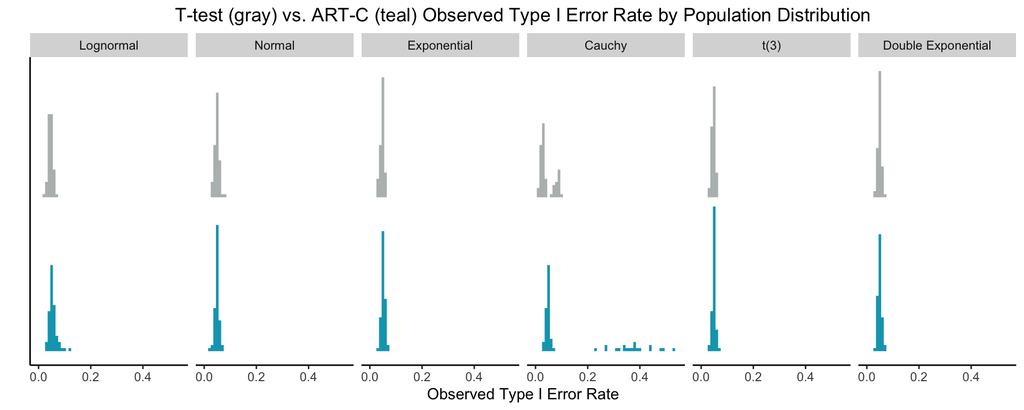

```r
# tick spacing
breaks.x = seq(0.05,1,0.1)

# labels are character versions of breaks
labels.x = as.character(breaks.x)

p=ggplot(df_same_loc) +
 geom_density( aes(x = Param_Proportion_Sig, y= ..count..), stat="binline", binwidth=.01, draw_baseline=FALSE, fill="azure4", color = NA, alpha=.6,
               position = position_nudge(y=50)) +
 geom_density( aes(x = ART_Con_Proportion_Sig, y= ..count..), stat="binline", binwidth=.01, draw_baseline=FALSE, fill=teal, color=NA) +
theme+
  # set x-axis label
  xlab("Observed Type I Error Rate") +
  # set y-axis label to nothing
  ylab("") +
  facet_wrap(~Population_Distribution, nrow=1) +
  #scale_x_continuous(breaks = breaks.x, label = labels.x, limits = c(0,.45)) +
  labs(title = "T-test (gray) vs. ART-C (teal) Observed Type I Error Rate by Population Distribution")

# show plot p
p
```

As expected, Type I error is similar among all Population Distributions except ART-C inflates Type I error when used to analyze data drawn from a Cauchy distribution.

# Power

The last step in validating ART-C is to see if it has high statistical power. To recap, statistical power is the probability that a method will find a true difference. We compared ART-C statistical power to: a *t*-test, Mann-Whitney *U* test for between-subjects designs and Wilcoxon signed-rank test signed rank test for within-subjects designs.

First, let’s look at some overall descriptive stats for all methods.

```
## ART-C power mean 0.5981218
```

```
## ART-C power SD 0.1432977
```

```
## t-test power mean 0.4624148
```

```
## t-test power SD 0.2078816
```

```
## Mann-Whitney U test / Wilcoxon signed rank test power mean 0.5225028
```

```
## Mann-Whitney U test / Wilcoxon signed rank test power SD 0.1477614
```

Overall, ART-C has greater power than the other methods. When we looked through our data, we saw that most of the design properties didn’t impact the differences between methods’ power. Condition Sample Size and Population Distribution were both interesting so we focus on those here. Again, you can look into this more on your own by tweaking the source code for this notebook.

### Power by Condition Sample Size

Some descriptive stats:

ART-C

```r
# descriptive statistics broken down by distribution type - ART-C
ddply(df_diff_loc, .(Condition_Sample_Size), summarize, mean = mean(ART_Con_Proportion_Sig), sd = sd(ART_Con_Proportion_Sig))
```

```
##   Condition_Sample_Size      mean        sd
## 1                     8 0.4323934 0.1080926
## 2                    16 0.5594330 0.1137514
## 3                    24 0.6334287 0.1104768
## 4                    32 0.6675345 0.1020046
## 5                    40 0.6978194 0.1044916
```

*T*-test

```r
# descriptive statistics broken down by distribution type - t-test
ddply(df_diff_loc, .(Condition_Sample_Size), summarize, mean = mean(Param_Proportion_Sig), sd = sd(Param_Proportion_Sig))
```

```
##   Condition_Sample_Size      mean        sd
## 1                     8 0.3267324 0.1328760
## 2                    16 0.4265947 0.1785088
## 3                    24 0.4889741 0.2022055
## 4                    32 0.5200077 0.2146672
## 5                    40 0.5497652 0.2234798
```

Mann-Whitney *U* Test / Wilcoxon Signed Rank Test

```r
# descriptive statistics broken down by distribution type - nonparam
ddply(df_diff_loc, .(Condition_Sample_Size), summarize, mean = mean(Nonparam_Proportion_Sig), sd = sd(Nonparam_Proportion_Sig))
```

```
##   Condition_Sample_Size      mean         sd
## 1                     8 0.3283923 0.08560591
## 2                    16 0.4733339 0.10357536
## 3                    24 0.5602824 0.10323825
## 4                    32 0.6074496 0.09384427
## 5                    40 0.6430559 0.09307663
```

All methods’ power increased with Condition Sample Size, but their relative differences remained the same, and ART-C always had the greater power than the other methods.

Visualizing:

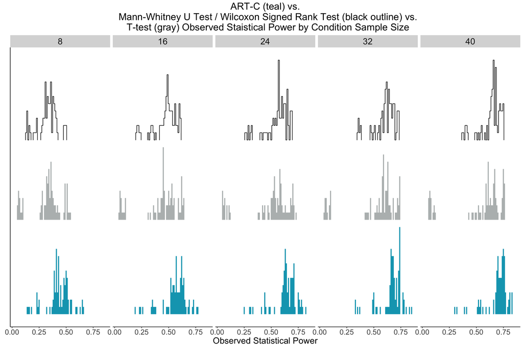

```r
p = ggplot(df_diff_loc) +
  geom_density( aes(x = Nonparam_Proportion_Sig, y= ..count..), stat="binline", binwidth=.01, draw_baseline=FALSE, fill="white",position = position_nudge(y=24))+
 geom_density( aes(x = Param_Proportion_Sig, y= ..count..), stat="binline", binwidth=.01, draw_baseline=FALSE, fill="azure4", color=NA, alpha=.6, position = position_nudge(y = 13)) +
   geom_density( aes(x = ART_Con_Proportion_Sig, y= ..count..), stat="binline", binwidth=.01, draw_baseline=FALSE, fill=teal,color=NA) +
  theme +
  theme(plot.title = element_text(color = "black",hjust=.5,size=20),
        axis.text.x = element_text(size=15), axis.title.x = element_text(size=18),
        strip.text.x = element_text(size=18)) +
  xlab("Observed Statistical Power") +
  ylab("") +
  facet_wrap(~Condition_Sample_Size, nrow=1)+
  labs(title = "ART-C (teal) vs.
  Mann-Whitney U Test / Wilcoxon Signed Rank Test (black outline) vs.
  T-test (gray) Observed Staistical Power by Condition Sample Size")

p
```

### Power by Population Distribution

The other design property that had an impact on power was Population Distribution.

ART-C

```r
# descriptive statistics broken down by distribution type - ART-C
ddply(df_diff_loc, .(Population_Distribution), summarize, mean = mean(ART_Con_Proportion_Sig), sd = sd(ART_Con_Proportion_Sig))
```

```
##   Population_Distribution      mean        sd
## 1               Lognormal 0.6865944 0.1018846
## 2                  Normal 0.6570850 0.0909288
## 3             Exponential 0.6606709 0.1083136
## 4                  Cauchy 0.4056335 0.1346811
## 5                    t(3) 0.5779982 0.1090603
## 6      Double Exponential 0.6007488 0.1040977
```

*T*-test

```r
# descriptive statistics broken down by distribution type - t-test
ddply(df_diff_loc, .(Population_Distribution), summarize, mean = mean(Param_Proportion_Sig), sd = sd(Param_Proportion_Sig))
```

```
##   Population_Distribution       mean         sd
## 1               Lognormal 0.46286871 0.10991417
## 2                  Normal 0.65928062 0.09091467
## 3             Exponential 0.51884954 0.11902740
## 4                  Cauchy 0.07391699 0.02142993
## 5                    t(3) 0.50188099 0.10281525
## 6      Double Exponential 0.55769188 0.10207533
```

Mann-Whitney *U* Test / Wilcoxon Signed Rank Test Power

```r
# descriptive statistics broken down by distribution type - nonparam
ddply(df_diff_loc, .(Population_Distribution), summarize, mean = mean(Nonparam_Proportion_Sig), sd = sd(Nonparam_Proportion_Sig))
```

```
##   Population_Distribution      mean        sd
## 1               Lognormal 0.5826765 0.1190024
## 2                  Normal 0.5942452 0.1174355
## 3             Exponential 0.5586135 0.1245237
## 4                  Cauchy 0.3438525 0.1237962
## 5                    t(3) 0.5166073 0.1263100
## 6      Double Exponential 0.5390220 0.1222124
```

Visualizing:

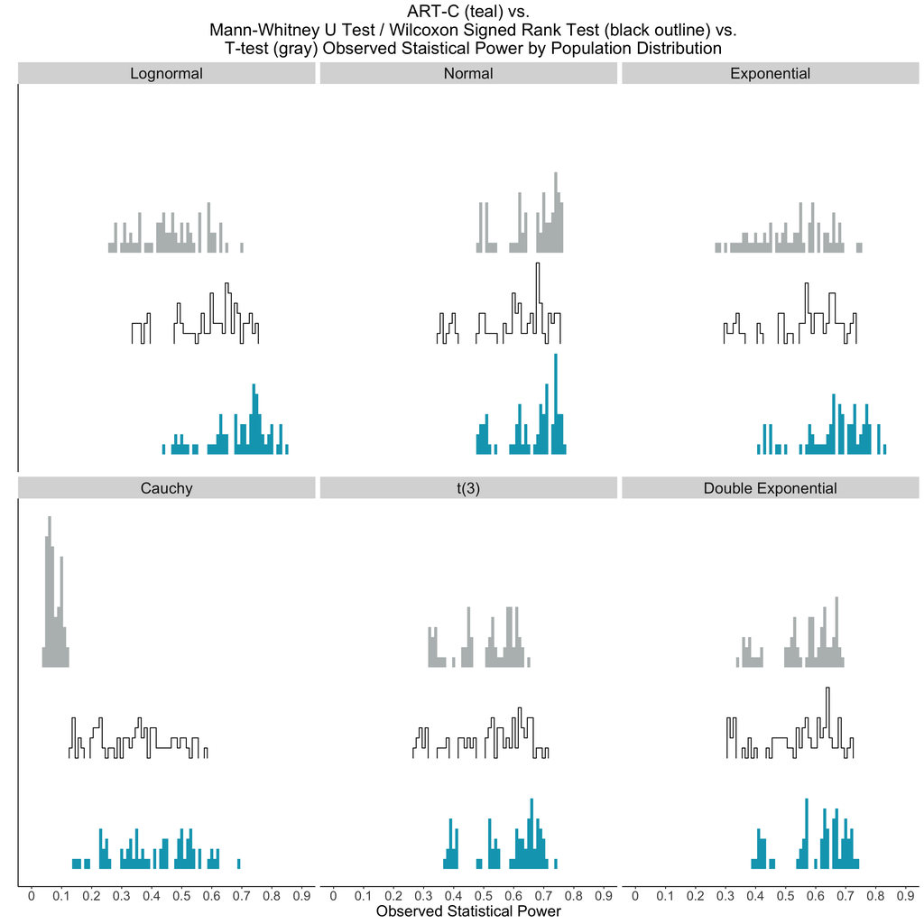

```r
# tick spacing
breaks.x = seq(0,.9,0.1)

# labels are character versions of breaks
labels.x = as.character(breaks.x)

# plot histogram of power for artcon, param, and nonparam overlapping.
p = ggplot(df_diff_loc) +
  geom_density( aes(x = Nonparam_Proportion_Sig, y= ..count..), stat="binline", binwidth=.01, draw_baseline=FALSE, fill="white",position = position_nudge(y=11))+
 geom_density( aes(x = Param_Proportion_Sig, y= ..count..), stat="binline", binwidth=.01, draw_baseline=FALSE, fill="azure4", color=NA, alpha=.6, position = position_nudge(y = 20)) +
   geom_density( aes(x = ART_Con_Proportion_Sig, y= ..count..), stat="binline", binwidth=.01, draw_baseline=FALSE, fill=teal,color=NA) +
  theme+
  theme(plot.title = element_text(color = "black",hjust=.5,size=20),
      axis.text.x = element_text(size=15), axis.title.x = element_text(size=18),
      strip.text.x = element_text(size=18)) +
  xlab("Observed Statistical Power") +
  ylab("") +
  scale_x_continuous(breaks = breaks.x, label = labels.x, limits = c(breaks.x[[1]],    breaks.x[length(breaks.x)])) +
  facet_wrap(~Population_Distribution, ncol=3)+
  labs(title = "ART-C (teal) vs.
  Mann-Whitney U Test / Wilcoxon Signed Rank Test (black outline) vs.
  T-test (gray) Observed Staistical Power by Population Distribution")

p
```

ART-C had greater power than a *t*-test for all non-normal distributions (to be expected since the *t*-test is meant for normal distributions) and greater power than Mann-Whitney *U* test / Wilcoxon signed rank test for all distributions.

Those are the most important results and the ones we included in our paper, but we can look at how the other properties impacted power, too.

### Power by Layout

Some descriptive stats:

ART-C

```r
# descriptive statistics broken down by distribution type - ART-C
ddply(df_diff_loc, .(Layout), summarize, mean = mean(ART_Con_Proportion_Sig), sd = sd(ART_Con_Proportion_Sig))
```

```
##   Layout      mean        sd
## 1    2x2 0.5783662 0.1559152
## 2    3x3 0.6088640 0.1297097
## 3  2x2x2 0.6041308 0.1426348
```

*T*-test

```r
# descriptive statistics broken down by distribution type - t-test
ddply(df_diff_loc, .(Layout), summarize, mean = mean(Param_Proportion_Sig), sd = sd(Param_Proportion_Sig))
```

```
##   Layout      mean        sd
## 1    2x2 0.4715979 0.2115065
## 2    3x3 0.4549774 0.2048659
## 3  2x2x2 0.4612510 0.2083735
```

Mann-Whitney *U* Test / Wilcoxon Signed Rank Test

```r
# descriptive statistics broken down by distribution type - nonparam
ddply(df_diff_loc, .(Layout), summarize, mean = mean(Nonparam_Proportion_Sig), sd = sd(Nonparam_Proportion_Sig))
```

```
##   Layout      mean        sd
## 1    2x2 0.5278437 0.1516542
## 2    3x3 0.5253806 0.1503611
## 3  2x2x2 0.5170238 0.1439876
```

Visualizing:

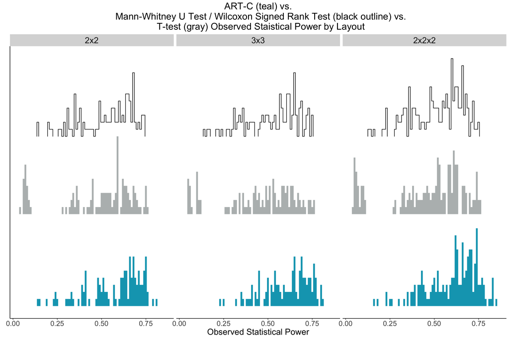

```r
p = ggplot(df_diff_loc) +
  geom_density( aes(x = Nonparam_Proportion_Sig, y= ..count..), stat="binline", binwidth=.01, draw_baseline=FALSE, fill="white",position = position_nudge(y=24))+
 geom_density( aes(x = Param_Proportion_Sig, y= ..count..), stat="binline", binwidth=.01, draw_baseline=FALSE, fill="azure4", color=NA, alpha=.6, position = position_nudge(y = 13)) +
   geom_density( aes(x = ART_Con_Proportion_Sig, y= ..count..), stat="binline", binwidth=.01, draw_baseline=FALSE, fill=teal,color=NA) +
  theme +
  theme(plot.title = element_text(color = "black",hjust=.5,size=20),
        axis.text.x = element_text(size=15), axis.title.x = element_text(size=18),
        strip.text.x = element_text(size=18)) +
  xlab("Observed Statistical Power") +
  ylab("") +
  #scale_x_continuous(breaks = breaks.x, label = labels.x, limits = c(breaks.x[[1]],    breaks.x[length(breaks.x)])) +
  facet_wrap(~Layout, nrow=1)+
  labs(title = "ART-C (teal) vs.
  Mann-Whitney U Test / Wilcoxon Signed Rank Test (black outline) vs.
  T-test (gray) Observed Staistical Power by Layout")

p
```

### Power by Between or Within Subjects

Some descriptive stats:

ART-C

```r
# descriptive statistics broken down by distribution type - ART-C
ddply(df_diff_loc, .(BW), summarize, mean = mean(ART_Con_Proportion_Sig), sd = sd(ART_Con_Proportion_Sig))
```

```
##                 BW      mean        sd
## 1 Between Subjects 0.6027286 0.1425443
## 2  Within Subjects 0.5935151 0.1442401
```

*T*-test

```r
# descriptive statistics broken down by distribution type - t-test
ddply(df_diff_loc, .(BW), summarize, mean = mean(Param_Proportion_Sig), sd = sd(Param_Proportion_Sig))
```

```
##                 BW      mean        sd
## 1 Between Subjects 0.4709494 0.2102342
## 2  Within Subjects 0.4538802 0.2056490
```

Mann-Whitney *U* Test / Wilcoxon Signed Rank Test

```r
# descriptive statistics broken down by distribution type - nonparam
ddply(df_diff_loc, .(BW), summarize, mean = mean(Nonparam_Proportion_Sig), sd = sd(Nonparam_Proportion_Sig))
```

```
##                 BW      mean        sd
## 1 Between Subjects 0.5418394 0.1357906
## 2  Within Subjects 0.5031662 0.1567829
```

Visualizing:

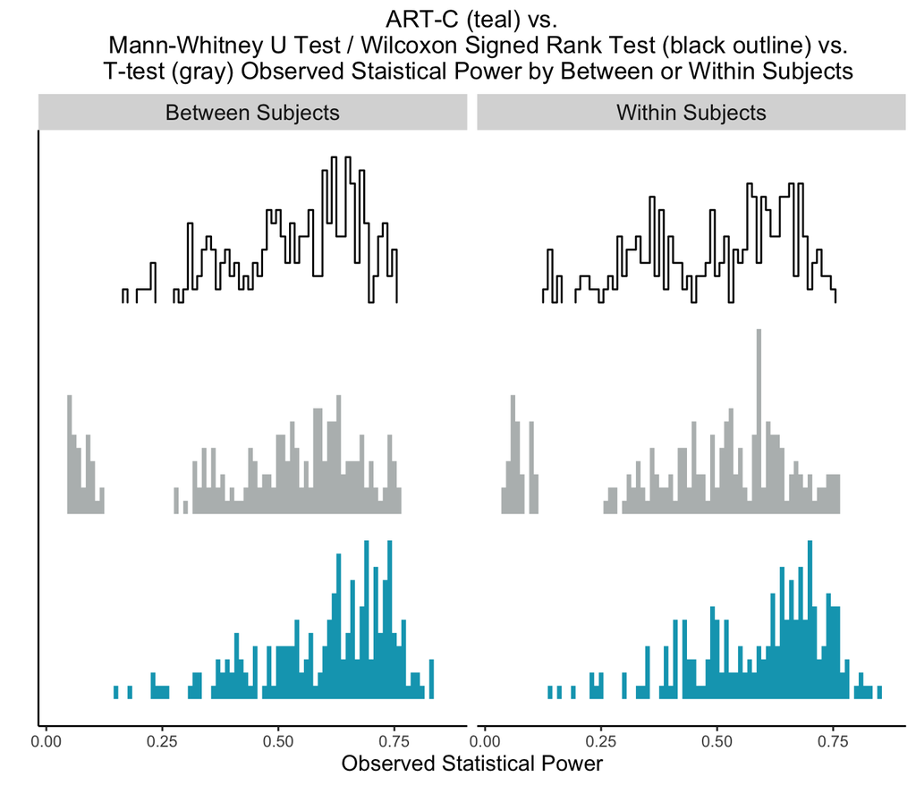

```r
p = ggplot(df_diff_loc) +
  geom_density( aes(x = Nonparam_Proportion_Sig, y= ..count..), stat="binline", binwidth=.01, draw_baseline=FALSE, fill="white",position = position_nudge(y=30))+
 geom_density( aes(x = Param_Proportion_Sig, y= ..count..), stat="binline", binwidth=.01, draw_baseline=FALSE, fill="azure4", color=NA, alpha=.6, position = position_nudge(y = 14)) +
   geom_density( aes(x = ART_Con_Proportion_Sig, y= ..count..), stat="binline", binwidth=.01, draw_baseline=FALSE, fill=teal,color=NA) +
  theme +
  theme(axis.title.x = element_text(size=12),
        strip.text.x = element_text(size=12)) +
  xlab("Observed Statistical Power") +
  ylab("") +
  #scale_x_continuous(breaks = breaks.x, label = labels.x, limits = c(breaks.x[[1]],    breaks.x[length(breaks.x)])) +
  facet_wrap(~BW, nrow=1)+
  labs(title = "ART-C (teal) vs.
  Mann-Whitney U Test / Wilcoxon Signed Rank Test (black outline) vs.
  T-test (gray) Observed Staistical Power by Between or Within Subjects")

p
```

### Power by Contrast Size

Some descriptive stats:

ART-C

```r
# descriptive statistics broken down by distribution type - ART-C
ddply(df_diff_loc, .(Contrast_Size), summarize, mean = mean(ART_Con_Proportion_Sig), sd = sd(ART_Con_Proportion_Sig))
```

```
##        Contrast_Size      mean        sd
## 1 1-Factor Contrasts 0.6162018 0.1471774
## 2 2-Factor Contrasts 0.5829068 0.1416638
## 3 3-Factor Contrasts 0.5895269 0.1320799
```

*T*-test

```r
# descriptive statistics broken down by distribution type - t-test
ddply(df_diff_loc, .(Contrast_Size), summarize, mean = mean(Param_Proportion_Sig), sd = sd(Param_Proportion_Sig))
```

```
##        Contrast_Size      mean        sd
## 1 1-Factor Contrasts 0.4784241 0.2165214
## 2 2-Factor Contrasts 0.4533488 0.2024922
## 3 3-Factor Contrasts 0.4415848 0.1969550
```

Mann-Whitney *U* Test / Wilcoxon Signed Rank Test

```r
# descriptive statistics broken down by distribution type - nonparam
ddply(df_diff_loc, .(Contrast_Size), summarize, mean = mean(Nonparam_Proportion_Sig), sd = sd(Nonparam_Proportion_Sig))
```

```
##        Contrast_Size      mean        sd
## 1 1-Factor Contrasts 0.4958053 0.1378273
## 2 2-Factor Contrasts 0.5382353 0.1511952
## 3 3-Factor Contrasts 0.5553981 0.1550372
```

Visualizing:

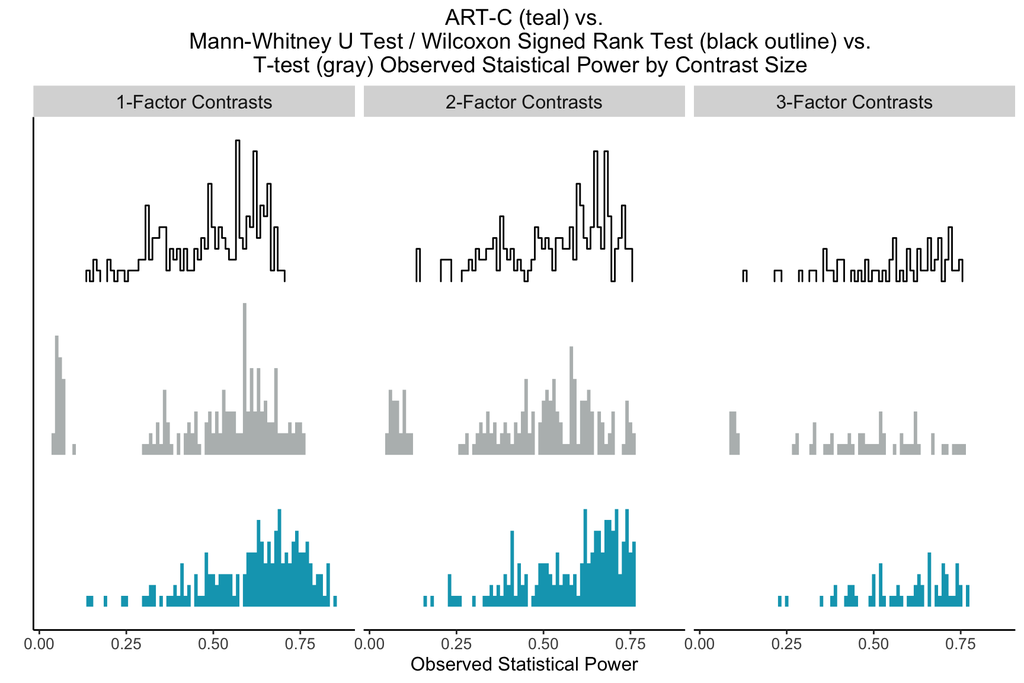

```r
p = ggplot(df_diff_loc) +
  geom_density( aes(x = Nonparam_Proportion_Sig, y= ..count..), stat="binline", binwidth=.01, draw_baseline=FALSE, fill="white",position = position_nudge(y=30))+
 geom_density( aes(x = Param_Proportion_Sig, y= ..count..), stat="binline", binwidth=.01, draw_baseline=FALSE, fill="azure4", color=NA, alpha=.6, position = position_nudge(y = 14)) +
   geom_density( aes(x = ART_Con_Proportion_Sig, y= ..count..), stat="binline", binwidth=.01, draw_baseline=FALSE, fill=teal,color=NA) +
  theme +
  theme(plot.title = element_text(color = "black",hjust=.5,size=14),
        axis.text.x = element_text(size=10), axis.title.x = element_text(size=12),
        strip.text.x = element_text(size=12)) +
  xlab("Observed Statistical Power") +
  ylab("") +
  #scale_x_continuous(breaks = breaks.x, label = labels.x, limits = c(breaks.x[[1]],    breaks.x[length(breaks.x)])) +
  facet_wrap(~Contrast_Size, nrow=1)+
  labs(title = "ART-C (teal) vs.
  Mann-Whitney U Test / Wilcoxon Signed Rank Test (black outline) vs.
  T-test (gray) Observed Staistical Power by Contrast Size")

p
```

To summarize: When used to conduct multifactor contrasts, ART-C does not inflate Type I error rate (as oppose to the original ART) and has greater power than *t*-test, Mann-Whitney *U* test, Wilcoxon signed rank test, and the original ART.